# lab-03

### 1. Read in data

```r
met <- read.csv('met_all',
                header = TRUE, sep = ',')
```

### 2. Check dimensions

```r
dim(met)
```

```
[1] 2377343      30
```

```r
head(met)
```

```
  USAFID  WBAN year month day hour min  lat      lon elev wind.dir wind.dir.qc
1 690150 93121 2019     8   1    0  56 34.3 -116.166  696      220           5
2 690150 93121 2019     8   1    1  56 34.3 -116.166  696      230           5
3 690150 93121 2019     8   1    2  56 34.3 -116.166  696      230           5
4 690150 93121 2019     8   1    3  56 34.3 -116.166  696      210           5
5 690150 93121 2019     8   1    4  56 34.3 -116.166  696      120           5
6 690150 93121 2019     8   1    5  56 34.3 -116.166  696       NA           9
  wind.type.code wind.sp wind.sp.qc ceiling.ht ceiling.ht.qc ceiling.ht.method
1              N     5.7          5      22000             5                 9
2              N     8.2          5      22000             5                 9
3              N     6.7          5      22000             5                 9
4              N     5.1          5      22000             5                 9
5              N     2.1          5      22000             5                 9
6              C     0.0          5      22000             5                 9
  sky.cond vis.dist vis.dist.qc vis.var vis.var.qc temp temp.qc dew.point
1        N    16093           5       N          5 37.2       5      10.6
2        N    16093           5       N          5 35.6       5      10.6
3        N    16093           5       N          5 34.4       5       7.2
4        N    16093           5       N          5 33.3       5       5.0
5        N    16093           5       N          5 32.8       5       5.0
6        N    16093           5       N          5 31.1       5       5.6
  dew.point.qc atm.press atm.press.qc       rh
1            5    1009.9            5 19.88127
2            5    1010.3            5 21.76098
3            5    1010.6            5 18.48212
4            5    1011.6            5 16.88862
5            5    1012.7            5 17.38410
6            5    1012.7            5 20.01540
```

```r
tail(met)
```

```
        USAFID  WBAN year month day hour min    lat      lon elev wind.dir
2377338 726813 94195 2019     8  31   18  56 43.650 -116.633  741       NA
2377339 726813 94195 2019     8  31   19  56 43.650 -116.633  741       70
2377340 726813 94195 2019     8  31   20  56 43.650 -116.633  741       NA
2377341 726813 94195 2019     8  31   21  56 43.650 -116.633  741       10
2377342 726813 94195 2019     8  31   22  56 43.642 -116.636  741       10
2377343 726813 94195 2019     8  31   23  56 43.642 -116.636  741       40
        wind.dir.qc wind.type.code wind.sp wind.sp.qc ceiling.ht ceiling.ht.qc
2377338           9              C     0.0          5      22000             5
2377339           5              N     2.1          5      22000             5
2377340           9              C     0.0          5      22000             5
2377341           5              N     2.6          5      22000             5
2377342           1              N     2.1          1      22000             1
2377343           1              N     2.1          1      22000             1
        ceiling.ht.method sky.cond vis.dist vis.dist.qc vis.var vis.var.qc temp
2377338                 9        N    16093           5       N          5 30.0
2377339                 9        N    16093           5       N          5 32.2
2377340                 9        N    16093           5       N          5 33.3
2377341                 9        N    14484           5       N          5 35.0
2377342                 9        N    16093           1       9          9 34.4
2377343                 9        N    16093           1       9          9 34.4
        temp.qc dew.point dew.point.qc atm.press atm.press.qc       rh
2377338       5      11.7            5    1013.6            5 32.32509
2377339       5      12.2            5    1012.8            5 29.40686
2377340       5      12.2            5    1011.6            5 27.60422
2377341       5       9.4            5    1010.8            5 20.76325
2377342       1       9.4            1    1010.1            1 21.48631
2377343       1       9.4            1    1009.6            1 21.48631
```

There are 30 columns and 2377343 rows.

### 3. Check variables

```r
str(met)
```

```
'data.frame':   2377343 obs. of  30 variables:
 $ USAFID           : int  690150 690150 690150 690150 690150 690150 690150 690150 690150 690150 ...
 $ WBAN             : int  93121 93121 93121 93121 93121 93121 93121 93121 93121 93121 ...
 $ year             : int  2019 2019 2019 2019 2019 2019 2019 2019 2019 2019 ...
 $ month            : int  8 8 8 8 8 8 8 8 8 8 ...
 $ day              : int  1 1 1 1 1 1 1 1 1 1 ...
 $ hour             : int  0 1 2 3 4 5 6 7 8 9 ...
 $ min              : int  56 56 56 56 56 56 56 56 56 56 ...
 $ lat              : num  34.3 34.3 34.3 34.3 34.3 34.3 34.3 34.3 34.3 34.3 ...
 $ lon              : num  -116 -116 -116 -116 -116 ...
 $ elev             : int  696 696 696 696 696 696 696 696 696 696 ...
 $ wind.dir         : int  220 230 230 210 120 NA 320 10 320 350 ...
 $ wind.dir.qc      : chr  "5" "5" "5" "5" ...
 $ wind.type.code   : chr  "N" "N" "N" "N" ...
 $ wind.sp          : num  5.7 8.2 6.7 5.1 2.1 0 1.5 2.1 2.6 1.5 ...
```

[output cut: 16 more lines]

### 4. Check key variables

```r
table(met$year)
```

```
   2019
2377343
```

```r
table(met$day)
```

```
    1     2     3     4     5     6     7     8     9    10    11    12    13
75975 75923 76915 76594 76332 76734 77677 77766 75366 75450 76187 75052 76906
   14    15    16    17    18    19    20    21    22    23    24    25    26
77852 76217 78015 78219 79191 76709 75527 75786 78312 77413 76965 76806 79114
   27    28    29    30    31
79789 77059 71712 74931 74849
```

```r
table(met$hour)
```

```
     0      1      2      3      4      5      6      7      8      9     10
 99434  93482  93770  96703 110504 112128 106235 101985 100310 102915 101880
    11     12     13     14     15     16     17     18     19     20     21
100470 103605  97004  96507  97635  94942  94184 100179  94604  94928  96070
    22     23
 94046  93823
```

```r
table(met$temp)
```

```
  -40 -17.2   -17    -3  -2.4    -2  -1.7  -1.5  -1.1    -1  -0.8  -0.6  -0.2
   36     6     8     4     1    10     2     1     1    22     5     3     3
 -0.1     0   0.1   0.2   0.3   0.4   0.5   0.6   0.7   0.8   0.9     1   1.1
    3    59     6     6     3     3     3    15     7     2     9    95    27
  1.2   1.3   1.4   1.5   1.6   1.7   1.8   1.9     2   2.1   2.2   2.3   2.4
    7     7     1     7     3    35    10     7   163    14    63    10    11
  2.5   2.6   2.7   2.8   2.9     3   3.1   3.2   3.3   3.4   3.5   3.6   3.7
   13    12    13    82    22   311    23    24    86    16    23    25    29
  3.8   3.9     4   4.1   4.2   4.3   4.4   4.5   4.6   4.7   4.8   4.9     5
   25   147   382    21    34    17   181    44    34    26    44    30   997
  5.1   5.2   5.3   5.4   5.5   5.6   5.7   5.8   5.9     6   6.1   6.2   6.3
   53    45    44    43    69   378    61    57    48  1523   465    71    59
  6.4   6.5   6.6   6.7   6.8   6.9     7   7.1   7.2   7.3   7.4   7.5   7.6
   65   104   104   601    95    83  2476   104   696   119    83   165   138
  7.7   7.8   7.9     8   8.1   8.2   8.3   8.4   8.5   8.6   8.7   8.8   8.9
  132   846   110  3541   183   204  1192   186   273   240   238   177  1403
    9   9.1   9.2   9.3   9.4   9.5   9.6   9.7   9.8   9.9    10  10.1  10.2
 3367   288   262   219  1630   398   327   351   276   261  7886   421   372
 10.3  10.4  10.5  10.6  10.7  10.8  10.9    11  11.1  11.2  11.3  11.4  11.5
  339   298   587  2545   419   399   329  9141  3232   531   473   403   892
 11.6  11.7  11.8  11.9    12  12.1  12.2  12.3  12.4  12.5  12.6  12.7  12.8
  633  3686   572   476 14123   820  4647   645   544  1317  1007   945  5169
 12.9    13  13.1  13.2  13.3  13.4  13.5  13.6  13.7  13.8  13.9    14  14.1
  650 17184  1066  1103  6459   777  1732  1286  1219  1213  7283 18282  1418
 14.2  14.3  14.4  14.5  14.6  14.7  14.8  14.9    15  15.1  15.2  15.3  15.4
 1276  1112  8202  2116  1688  1555  1306  1028 31602  1690  1849  1416  1046
 15.5  15.6  15.7  15.8  15.9    16  16.1  16.2  16.3  16.4  16.5  16.6  16.7
 2643 11800  1716  1581  1172 27734 13655  2046  1781  1401  3292  2537 15183
 16.8  16.9    17  17.1  17.2  17.3  17.4  17.5  17.6  17.7  17.8  17.9    18
 1976  1519 35549  2748 17492  2262  1609  4174  2974  2857 18998  1774 42325
 18.1  18.2  18.3  18.4  18.5  18.6  18.7  18.8  18.9    19  19.1  19.2  19.3
 3302  3199 21444  1950  5239  3536  3359  3020 21917 40269  4029  3781  3119
 19.4  19.5  19.6  19.7  19.8  19.9    20  20.1  20.2  20.3  20.4  20.5  20.6
24987  5779  4098  3744  3120  2466 70325  4520  4132  3482  2656  6446 29934
 20.7  20.8  20.9    21  21.1  21.2  21.3  21.4  21.5  21.6  21.7  21.8  21.9
 4287  3668  2753 56445 31912  4545  4075  2969  7073  5320 33138  3979  3129
   22  22.1  22.2  22.3  22.4  22.5  22.6  22.7  22.8  22.9    23  23.1  23.2
63828  5095 33412  4115  3163  7483  5076  4924 35025  3320 64776  5147  4864
 23.3  23.4  23.5  23.6  23.7  23.8  23.9    24  24.1  24.2  24.3  24.4  24.5
33659  3434  7361  5272  4938  4515 33134 52759  5584  5206  4488 33190  7966
```

[output cut: 21 more lines]

```
  528   466  2400   370  2923   366   333  1723   303   321   266   258   240
 38.9    39  39.1  39.2  39.3  39.4  39.5  39.6  39.7  39.8  39.9    40  40.1
 1384  1532   208   184   178  1071   174   147   126   116   110  1413    83
 40.2  40.3  40.4  40.5  40.6  40.7  40.8  40.9    41  41.1  41.2  41.3  41.4
   71    70    56    53   536    45    30    34   592   449    26    18    10
 41.5  41.6  41.7  41.8  41.9    42  42.1  42.2  42.3  42.4  42.5  42.6  42.7
   20    17   339    11    11   427    11   250    15    11    10     3     6
 42.8  42.9    43  43.1  43.2  43.3  43.4  43.5  43.6  43.7  43.8  43.9    44
  186     6   215     9     1   116     3     2     3     7     4    95   164
 44.2  44.3  44.4  44.5  44.6  44.7  44.8  44.9    45  45.6    46  46.1  46.7
    4     1    81     1     2     2     1     1   127    34    37    20    19
   47  47.2  47.8  48.3  48.9  49.4    50  50.6  51.1  51.7    52  52.8  53.9
   11     7     4     5     2     1     4     2     2     3     1     2     1
 54.4    56
    1     1
```

```r
table(met$elev)
```

```
  -13   -12     0     1     2     3     4     5     6     7     8     9    10
    8   791  5311  3437 10991 21965 14247 26768 21248 20041 15514 16049 11207
   11    12    13    14    15    16    17    18    19    20    21    22    23
 4398  8393  8597  8909 12953  7422  9669  3046  4056  9546 14349  5800 10971
   24    25    26    27    28    29    30    31    32    33    34    35    36
 9820 10827  4167  7845  4471  3865 10588  7744  3231  5913 10671   778  5586
   37    38    39    40    41    43    44    45    46    47    48    49    50
 6262  3653  2237  2998  6812  7349  4130  6126  1975  3278  3854  1010  3118
   51    52    53    54    55    56    57    58    59    60    61    62    63
 5321  2122  3849  3408  5945  2935  6976  3167  7346  3165  1038  4505  2160
   64    65    66    67    68    69    70    71    72    73    74    75    77
 1317 11541  1485  7613   924  3439  2167  2314   838  6013  3444  8680  1144
   78    79    80    82    83    84    85    87    88    89    90    91    92
 7329  1924  4422  1164  2032  3286  2568  3582  1040  1053  4284  3097  7296
   93    94    95    96    97    98    99   100   101   102   103   104   105
```

[output cut: 121 more lines]

```r
table(met$wind.sp)
```

```
     0    0.5      1    1.3    1.5    1.8    2.1    2.2    2.6    2.7      3
642539     35    121      8 264617      1 264802     15 237358      3      3
   3.1    3.5    3.6      4    4.1    4.4    4.5    4.6      5    5.1    5.7
202651     24 165888     18 133069      2      1 102006      5  78519  57372
     6    6.2    6.7      7    7.2    7.7      8    8.2    8.8      9    9.3
     4  42386  30639      3  21918  15430      3  11232   7782      3   5509
   9.8     10   10.3   10.8   11.3   11.8   12.4   12.9   13.4   13.9   14.4
  3800      2   2770   1893   1351    894    651    464    364    283    218
  14.9   15.4     16   16.5     17   17.5     18   18.5     19   19.6   20.1
   152    143    109     79     88     76     76     51     33     28     29
  20.6   21.1   21.6   22.1   22.7   23.2   23.7   24.2   24.7   25.2   25.7
    18     22     16     12     11     10      4      8      6      6      6
  26.3   26.8   27.3   27.8   28.3     36
     2      2      1      2      1      3
```

```r
library(dplyr)
# replace 9999 with NA
met <- met %>%
  mutate(elev = na_if(elev, 9999))

# find max elev
summary(met$elev)
```

```
   Min. 1st Qu.  Median    Mean 3rd Qu.    Max.    NA's
    -13     101     252     413     400    4113     710
```

```r
# remove NA and -40C
met <- met[!is.na(met$elev), ]
met <- met[met$temp > -40, ]
summary(met$temp)
```

```
   Min. 1st Qu.  Median    Mean 3rd Qu.    Max.    NA's
 -17.20   19.60   23.50   23.59   27.80   56.00   59561
```

The highest weather station is at 4113 elevation. The new lowest temperature is -17.2C.

### 5. Check with external data source

```r
summary(met$elev)
```

```
   Min. 1st Qu.  Median    Mean 3rd Qu.    Max.    NA's
  -13.0   101.0   252.0   414.3   400.0  4113.0   59561
```

```r
met <- met[order(met$elev), ]
tail(met)
```

```
         USAFID WBAN year month day hour min lat lon elev wind.dir wind.dir.qc
NA.59555     NA   NA   NA    NA  NA   NA  NA  NA  NA   NA       NA        <NA>
NA.59556     NA   NA   NA    NA  NA   NA  NA  NA  NA   NA       NA        <NA>
NA.59557     NA   NA   NA    NA  NA   NA  NA  NA  NA   NA       NA        <NA>
NA.59558     NA   NA   NA    NA  NA   NA  NA  NA  NA   NA       NA        <NA>
NA.59559     NA   NA   NA    NA  NA   NA  NA  NA  NA   NA       NA        <NA>
NA.59560     NA   NA   NA    NA  NA   NA  NA  NA  NA   NA       NA        <NA>
         wind.type.code wind.sp wind.sp.qc ceiling.ht ceiling.ht.qc
NA.59555           <NA>      NA       <NA>         NA            NA
NA.59556           <NA>      NA       <NA>         NA            NA
NA.59557           <NA>      NA       <NA>         NA            NA
NA.59558           <NA>      NA       <NA>         NA            NA
NA.59559           <NA>      NA       <NA>         NA            NA
NA.59560           <NA>      NA       <NA>         NA            NA
         ceiling.ht.method sky.cond vis.dist vis.dist.qc vis.var vis.var.qc
NA.59555              <NA>     <NA>       NA        <NA>    <NA>       <NA>
NA.59556              <NA>     <NA>       NA        <NA>    <NA>       <NA>
NA.59557              <NA>     <NA>       NA        <NA>    <NA>       <NA>
NA.59558              <NA>     <NA>       NA        <NA>    <NA>       <NA>
NA.59559              <NA>     <NA>       NA        <NA>    <NA>       <NA>
NA.59560              <NA>     <NA>       NA        <NA>    <NA>       <NA>
         temp temp.qc dew.point dew.point.qc atm.press atm.press.qc rh
NA.59555   NA    <NA>        NA         <NA>        NA           NA NA
NA.59556   NA    <NA>        NA         <NA>        NA           NA NA
NA.59557   NA    <NA>        NA         <NA>        NA           NA NA
NA.59558   NA    <NA>        NA         <NA>        NA           NA NA
NA.59559   NA    <NA>        NA         <NA>        NA           NA NA
NA.59560   NA    <NA>        NA         <NA>        NA           NA NA
```

```r
met_temp <- met[order(met$temp), ]
head(met_temp)
```

```
        USAFID WBAN year month day hour min    lat    lon elev wind.dir
1203053 722817 3068 2019     8   1    0  56 38.767 -104.3 1838      190
1203055 722817 3068 2019     8   1    1  56 38.767 -104.3 1838      180
1203128 722817 3068 2019     8   3   11  56 38.767 -104.3 1838       NA
1203129 722817 3068 2019     8   3   12  56 38.767 -104.3 1838       NA
1203222 722817 3068 2019     8   6   21  56 38.767 -104.3 1838      280
1203225 722817 3068 2019     8   6   22  56 38.767 -104.3 1838      240
        wind.dir.qc wind.type.code wind.sp wind.sp.qc ceiling.ht ceiling.ht.qc
1203053           5              N     7.2          5         NA             9
1203055           5              N     7.7          5         NA             9
1203128           9              C     0.0          5         NA             9
1203129           9              C     0.0          5         NA             9
1203222           5              N     2.6          5         NA             9
1203225           5              N     7.7          5         NA             9
        ceiling.ht.method sky.cond vis.dist vis.dist.qc vis.var vis.var.qc
1203053                 9        N       NA           9       N          5
1203055                 9        N       NA           9       N          5
1203128                 9        N       NA           9       N          5
1203129                 9        N       NA           9       N          5
1203222                 9        N       NA           9       N          5
1203225                 9        N       NA           9       N          5
         temp temp.qc dew.point dew.point.qc atm.press atm.press.qc rh
1203053 -17.2       5        NA            9        NA            9 NA
1203055 -17.2       5        NA            9        NA            9 NA
1203128 -17.2       5        NA            9        NA            9 NA
1203129 -17.2       5        NA            9        NA            9 NA
1203222 -17.2       5        NA            9        NA            9 NA
1203225 -17.2       5        NA            9        NA            9 NA
```

### 6. Summary statistics

```r
met_maxelev <- met %>%
  filter(elev == 4113) %>%
  select(temp, wind.sp, hour, day) %>%
  filter(!is.na(wind.sp))
summary(met_maxelev)
```

```
      temp           wind.sp            hour            day
 Min.   : 1.000   Min.   : 0.000   Min.   : 0.00   Min.   : 1.00
 1st Qu.: 6.000   1st Qu.: 4.100   1st Qu.: 6.00   1st Qu.: 8.00
 Median : 8.000   Median : 6.700   Median :12.00   Median :16.00
 Mean   : 8.135   Mean   : 7.245   Mean   :11.69   Mean   :16.02
 3rd Qu.:10.000   3rd Qu.: 9.800   3rd Qu.:18.00   3rd Qu.:24.00
 Max.   :15.000   Max.   :21.100   Max.   :23.00   Max.   :31.00
```

```r
cor(met_maxelev)
```

```
                temp     wind.sp         hour          day
temp     1.000000000 -0.09373843  0.435680110 -0.006130763
wind.sp -0.093738431  1.00000000  0.088073152  0.364307915
hour     0.435680110  0.08807315  1.000000000 -0.004546462
day     -0.006130763  0.36430791 -0.004546462  1.000000000
```

Temperature and hour and moderately correlated, with a correlation coefficient of 0.44. Wind speed and day are also moderately correlated, with a correlation coefficient of 0.36. Correlations only test for linear relationships so it may miss other relationships between variables that are not linear.

### 7. Exploratory graphs

```r
par(mfrow = c(2,2))
hist(met$elev)
hist(met$temp)
hist(met$wind.sp)

library(leaflet)
leaflet(met$elev) %>%
  addProviderTiles('OpenStreetMap') %>%
  addCircles(lat=39.8,lng=-105.766, opacity=1, fillOpacity=1, radius=100)
```

[interactive chart not shown]

```r
library(lubridate)
elev <- met %>%
  filter(elev == 4113) %>%
  filter(!is.na(wind.sp))

elev$date <- with(elev, ymd_h(paste(year, month, day, hour, sep= ' ')))
summary(elev$date)
```

```
                 Min.               1st Qu.                Median
"2019-08-01 00:00:00" "2019-08-08 06:00:00" "2019-08-16 17:00:00"
                 Mean               3rd Qu.                  Max.
"2019-08-16 12:13:41" "2019-08-24 13:00:00" "2019-08-31 22:00:00"
```

[output not shown]

[output cut: 20 more lines]

[figure not shown]

```r
elev <- elev[order(elev$date), ]
head(elev)
```

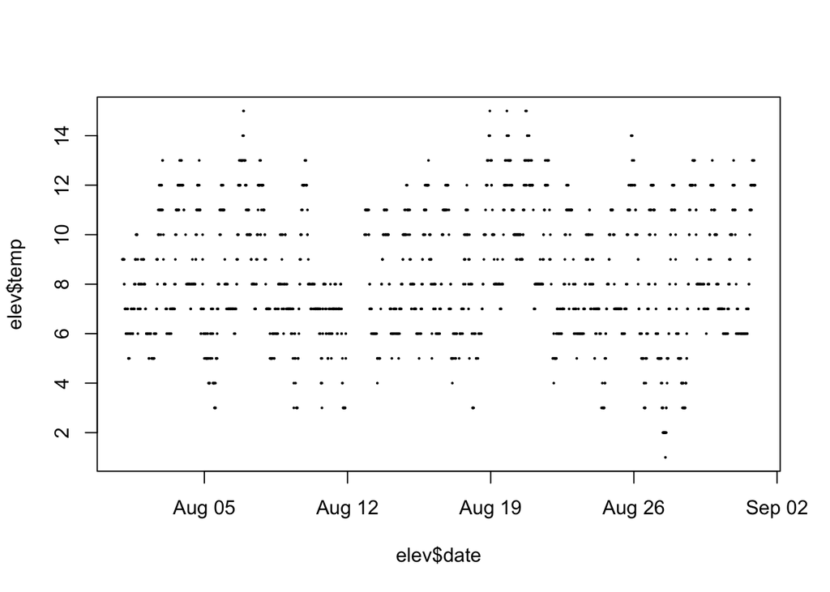

```r
plot(elev$date, elev$temp, pch=16, cex=0.3)
```

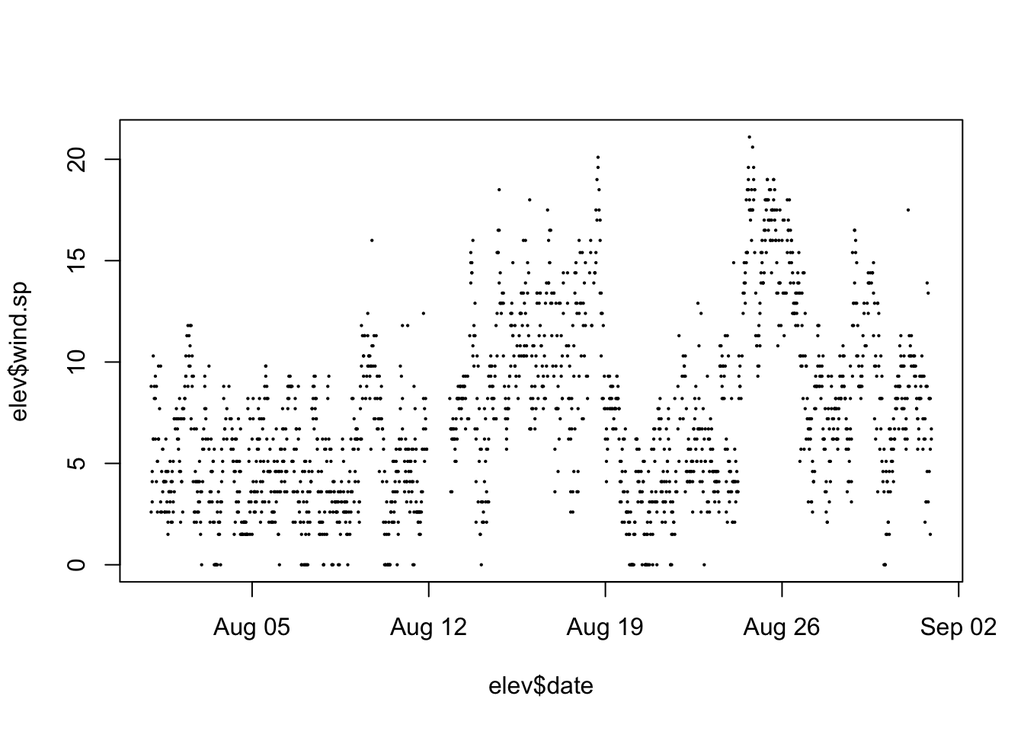

```r
plot(elev$date, elev$wind.sp, pch=16, cex=0.3)
```

The time series plot for temperature stays relatively within the same range, with some fluctuations. The plot for wind speed shows a couple of spikes around mid-August and end of August.

### 8. Questions

Why are there so many missing data for variables like temperature, elevation, and wind speed?

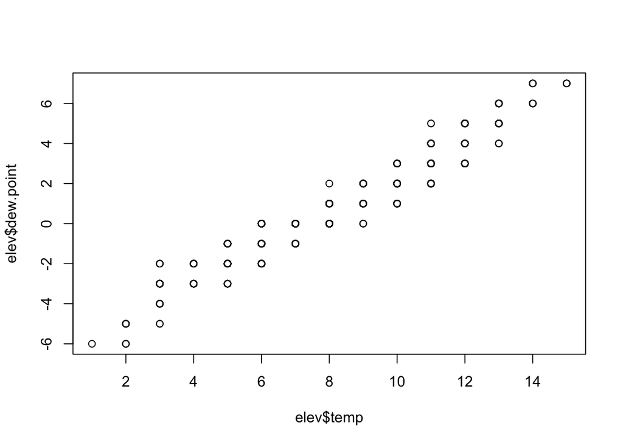

```r
plot(elev$temp, elev$dew.point)
```

It seems that temperature and dew point at the highest elevation have a very strong positive linear relationship, which is to be expected.